# The Danish Monarchy

Mia H. Knudsen

07/08/26

```r
knitr::opts_chunk$set(echo = TRUE)
library(tidyverse)
```

```r
library(knitr)
library(ggplot2)
```

The task here is to load your monarchs csv into R using the `tidyverse` toolkit, calculate and explore the kings’ duration of reign with pipes `%>%` in `dplyr` and plot it over time.

## Load the monarchs

Make sure to first create an `.Rproj` workspace with a `data/` folder where you place either your own dataset or the provided `monarchs.csv` dataset.

1. Look at the dataset that are you loading and check what its columns are separated by? (hint: open it in plain text editor to see)

List what is the

separator: ‘,’ or ‘;’

2. Create a `monarchs` object in R with the different functions below and inspect the different outputs.
- `read.csv()`
- `read_csv()`
- `read.csv2()`
- `read_csv2()`

```r
# FILL IN THE CODE BELOW and review the outputs

monarchs1 <- read.csv("data/dam_dansk_monarki.csv")

monarchs2 <- read_csv("data/dam_dansk_monarki.csv")
monarchs3 <- read.csv2("data/dam_dansk_monarki.csv")

monarchs4 <- read_csv2("data/dam_dansk_monarki.csv")
```

```
## ℹ Using "','" as decimal and "'.'" as grouping mark. Use `read_delim()` for more control.
```

Answer:

1. Which of these functions is a `tidyverse` function? Read data with it below into a `monarchs` object

‘read_csv’ and ‘read_csv2’ are tidyverse-functions whereas ‘read.csv’ and ‘read.csv2’ are from the base R

2. What is the result of running `class()` on the `monarchs` object created with a tidyverse function.

The ‘class()’ function tells R to show an object’s data type, i.e numeric, character, etc. Running ‘class()’ on a tidyverse data set results in the line ‘“spec_tbl_df” “tbl_df” “tbl” “data.frame”’ This is because a ‘tibble’ created with the tidyverse-functions has multiple ‘classes’

3. How many columns does the object have when created with these different functions?

My particular csv-file uses semicolon to separate values therefor when loading the file with ‘read.csv’ and ‘read_csv’, which use comma to separate values, the table is object is loaded as having a single column. When using ‘read.csv2’ and ‘read_csv2’, which use semicolon, the object is loaded correctly with the amounts of columns I created the table with, which in this case is 5

```r
ncol(monarchs1)
```

```
## [1] 1
```

```r
ncol(monarchs2)
```

```
## [1] 1
```

```r
ncol(monarchs3)
```

```
## [1] 5
```

```r
ncol(monarchs4)
```

```
## [1] 5
```

4. Show the dataset so that we can see how R interprets each column

```r
monarchs <- read_csv2("data/dam_dansk_monarki.csv")
```

```
## ℹ Using "','" as decimal and "'.'" as grouping mark. Use `read_delim()` for more control.
```

```r
class(monarchs)
```

```
## [1] "spec_tbl_df" "tbl_df"      "tbl"         "data.frame"
```

```r
(monarchs)
```

```
## # A tibble: 55 × 5
##    name               birth_year death_year reign_start_year reign_end_year
##    <chr>                   <dbl>      <dbl>            <dbl>          <dbl>
##  1 Gorm_den_gamle             NA        958               NA            958
##  2 Harald_1_blåtand           NA        987              958            987
##  3 Svend_1_tveskæg           963       1014              987           1014
##  4 Harald_2                   NA       1018             1014           1018
##  5 Knud_1_den_store          995       1035             1018           1035
##  6 Hardeknud                1020       1042             1035           1042
##  7 Magnus_den_gode          1024       1047             1042           1047
##  8 Svend_2_estridsen        1020       1076             1047           1076
##  9 Harald_3_hen             1040       1080             1076           1080
## 10 Knud_2_den_hellige       1042       1086             1080           1086
## # ℹ 45 more rows
```

```r
kable(monarchs)
```

| name | birth_year | death_year | reign_start_year | reign_end_year |
| --- | --- | --- | --- | --- |
| Gorm_den_gamle | NA | 958 | NA | 958 |
| Harald_1_blåtand | NA | 987 | 958 | 987 |
| Svend_1_tveskæg | 963 | 1014 | 987 | 1014 |
| Harald_2 | NA | 1018 | 1014 | 1018 |
| Knud_1_den_store | 995 | 1035 | 1018 | 1035 |
| Hardeknud | 1020 | 1042 | 1035 | 1042 |
| Magnus_den_gode | 1024 | 1047 | 1042 | 1047 |
| Svend_2_estridsen | 1020 | 1076 | 1047 | 1076 |
| Harald_3_hen | 1040 | 1080 | 1076 | 1080 |
| Knud_2_den_hellige | 1042 | 1086 | 1080 | 1086 |
| Oluf_1_hunger | 1050 | 1095 | 1086 | 1095 |
| Erik_1_ejegod | 1056 | 1103 | 1095 | 1103 |
| Niels | 1065 | 1134 | 1104 | 1134 |
| Erik_2_emune | 1090 | 1137 | 1134 | 1137 |
| Erik_3_lam | NA | 1146 | 1137 | 1146 |
| Svend_3_grathe | 1125 | 1157 | 1146 | 1157 |
| Knud_3_magnussen | 1128 | 1157 | 1146 | 1157 |
| Valdemar_1_den_store | 1131 | 1182 | 1157 | 1182 |
| Knud_4 | 1163 | 1202 | 1182 | 1202 |
| Valdemar_2_sejr | 1170 | 1241 | 1202 | 1241 |
| Erik_4_plovpenning | 1216 | 1250 | 1241 | 1250 |
| Abel | 1218 | 1252 | 1250 | 1252 |
| Christoffer_1 | 1219 | 1259 | 1252 | 1259 |
| Erik_5_klipping | 1249 | 1286 | 1259 | 1286 |
| Erik_6_menved | 1274 | 1319 | 1286 | 1319 |
| Christoffer_2 | 1276 | 1332 | 1320 | 1326 |
| Valdemar_3 | 1315 | 1364 | 1326 | 1330 |
| Christoffer_2 | 1276 | 1332 | 1329 | 1332 |
| Valdemar_4_atterdag | 1320 | 1375 | 1340 | 1375 |
| Oluf_2 | 1370 | 1387 | 1376 | 1387 |
| Margrete_1 | 1353 | 1412 | 1387 | 1396 |
| Erik_7_af_pommern | 1382 | 1459 | 1396 | 1439 |
| Christoffer_3_af_bayern | 1416 | 1448 | 1440 | 1448 |
| Christian_1 | 1426 | 1481 | 1448 | 1481 |
| Hans | 1455 | 1513 | 1482 | 1513 |
| Christian_2 | 1481 | 1559 | 1513 | 1523 |
| Frederik_1 | 1471 | 1533 | 1523 | 1533 |
| Christian_3 | 1503 | 1556 | 1536 | 1559 |
| Frederik_2 | 1534 | 1588 | 1559 | 1588 |
| Christian_4 | 1577 | 1648 | 1596 | 1648 |
| Frederik_3 | 1609 | 1670 | 1648 | 1670 |
| Christian_5 | 1646 | 1699 | 1670 | 1699 |
| Frederik_4 | 1671 | 1730 | 1699 | 1730 |
| Christian_6 | 1699 | 1746 | 1730 | 1746 |
| Frederik_5 | 1723 | 1766 | 1746 | 1766 |
| Christian_7 | 1749 | 1808 | 1766 | 1808 |
| Frederik_6 | 1768 | 1839 | 1808 | 1839 |
| Christian_8 | 1786 | 1848 | 1839 | 1848 |
| Frederik_7 | 1808 | 1863 | 1848 | 1863 |
| Christian_9 | 1818 | 1906 | 1863 | 1906 |
| Frederik_8 | 1843 | 1912 | 1906 | 1912 |
| Christian_10 | 1870 | 1947 | 1912 | 1947 |
| Frederik_9 | 1899 | 1972 | 1947 | 1972 |
| Margrethe_2 | 1940 | NA | 1972 | 2024 |
| Frederik_10 | 1968 | NA | 2024 | NA |

## Calculate the duration of reign for all the monarchs in your table

You can calculate the duration of reign in years with `mutate` function by subtracting the equivalents of your `startReign` from `endReign` columns and writing the result to a new column called `duration`. But first you need to check a few things:

- Is your data messy? Fix it before re-importing to R
- Do your start and end of reign columns contain NAs? Choose the right strategy to deal with them: `na.omit()`, `na.rm=TRUE`, `!is.na()`

Create a new column called `duration` in the monarchs dataset, utilizing the `mutate()` function from tidyverse. Check with your group to brainstorm the options.

```r
# YOUR CODE

monarchs_reign_length <- mutate(monarchs, duration = (reign_end_year - reign_start_year)) |> filter(!is.na(duration))

monarchs <- mutate(monarchs, duration = (reign_end_year - reign_start_year))

kable(monarchs)
```

| name | birth_year | death_year | reign_start_year | reign_end_year | duration |
| --- | --- | --- | --- | --- | --- |
| Gorm_den_gamle | NA | 958 | NA | 958 | NA |
| Harald_1_blåtand | NA | 987 | 958 | 987 | 29 |
| Svend_1_tveskæg | 963 | 1014 | 987 | 1014 | 27 |
| Harald_2 | NA | 1018 | 1014 | 1018 | 4 |
| Knud_1_den_store | 995 | 1035 | 1018 | 1035 | 17 |
| Hardeknud | 1020 | 1042 | 1035 | 1042 | 7 |
| Magnus_den_gode | 1024 | 1047 | 1042 | 1047 | 5 |
| Svend_2_estridsen | 1020 | 1076 | 1047 | 1076 | 29 |
| Harald_3_hen | 1040 | 1080 | 1076 | 1080 | 4 |
| Knud_2_den_hellige | 1042 | 1086 | 1080 | 1086 | 6 |
| Oluf_1_hunger | 1050 | 1095 | 1086 | 1095 | 9 |
| Erik_1_ejegod | 1056 | 1103 | 1095 | 1103 | 8 |
| Niels | 1065 | 1134 | 1104 | 1134 | 30 |
| Erik_2_emune | 1090 | 1137 | 1134 | 1137 | 3 |
| Erik_3_lam | NA | 1146 | 1137 | 1146 | 9 |
| Svend_3_grathe | 1125 | 1157 | 1146 | 1157 | 11 |
| Knud_3_magnussen | 1128 | 1157 | 1146 | 1157 | 11 |
| Valdemar_1_den_store | 1131 | 1182 | 1157 | 1182 | 25 |
| Knud_4 | 1163 | 1202 | 1182 | 1202 | 20 |
| Valdemar_2_sejr | 1170 | 1241 | 1202 | 1241 | 39 |
| Erik_4_plovpenning | 1216 | 1250 | 1241 | 1250 | 9 |
| Abel | 1218 | 1252 | 1250 | 1252 | 2 |
| Christoffer_1 | 1219 | 1259 | 1252 | 1259 | 7 |
| Erik_5_klipping | 1249 | 1286 | 1259 | 1286 | 27 |
| Erik_6_menved | 1274 | 1319 | 1286 | 1319 | 33 |
| Christoffer_2 | 1276 | 1332 | 1320 | 1326 | 6 |
| Valdemar_3 | 1315 | 1364 | 1326 | 1330 | 4 |
| Christoffer_2 | 1276 | 1332 | 1329 | 1332 | 3 |
| Valdemar_4_atterdag | 1320 | 1375 | 1340 | 1375 | 35 |
| Oluf_2 | 1370 | 1387 | 1376 | 1387 | 11 |
| Margrete_1 | 1353 | 1412 | 1387 | 1396 | 9 |
| Erik_7_af_pommern | 1382 | 1459 | 1396 | 1439 | 43 |
| Christoffer_3_af_bayern | 1416 | 1448 | 1440 | 1448 | 8 |
| Christian_1 | 1426 | 1481 | 1448 | 1481 | 33 |
| Hans | 1455 | 1513 | 1482 | 1513 | 31 |
| Christian_2 | 1481 | 1559 | 1513 | 1523 | 10 |
| Frederik_1 | 1471 | 1533 | 1523 | 1533 | 10 |
| Christian_3 | 1503 | 1556 | 1536 | 1559 | 23 |
| Frederik_2 | 1534 | 1588 | 1559 | 1588 | 29 |
| Christian_4 | 1577 | 1648 | 1596 | 1648 | 52 |
| Frederik_3 | 1609 | 1670 | 1648 | 1670 | 22 |
| Christian_5 | 1646 | 1699 | 1670 | 1699 | 29 |
| Frederik_4 | 1671 | 1730 | 1699 | 1730 | 31 |
| Christian_6 | 1699 | 1746 | 1730 | 1746 | 16 |
| Frederik_5 | 1723 | 1766 | 1746 | 1766 | 20 |
| Christian_7 | 1749 | 1808 | 1766 | 1808 | 42 |
| Frederik_6 | 1768 | 1839 | 1808 | 1839 | 31 |
| Christian_8 | 1786 | 1848 | 1839 | 1848 | 9 |
| Frederik_7 | 1808 | 1863 | 1848 | 1863 | 15 |
| Christian_9 | 1818 | 1906 | 1863 | 1906 | 43 |
| Frederik_8 | 1843 | 1912 | 1906 | 1912 | 6 |
| Christian_10 | 1870 | 1947 | 1912 | 1947 | 35 |
| Frederik_9 | 1899 | 1972 | 1947 | 1972 | 25 |
| Margrethe_2 | 1940 | NA | 1972 | 2024 | 52 |
| Frederik_10 | 1968 | NA | 2024 | NA | NA |

please note that while I have mutated the ‘monarchs’ tibble to include duration of reign for all monarchs, I have also defined a variable ‘monarchs_reign_length’ which contain the same data but with NA in the duration-column filtered away. I will be using the ‘monarchs_reign_length’ for further calculations regarding duration length

## Calculate the average duration of reign for all rulers

Do you remember how to calculate an average on a vector object? If not, review the last two lessons and remember that a column is basically a vector. So you need to subset your `monarchs` dataset to the `duration` column. If you subset it as a vector you can calculate average on it with `mean()` base-R function. If you subset it as a tibble, you can calculate average on it with `summarize()` tidyverse function. Try both ways!

- You first need to know how to select the relevant `duration` column. What are your options?
- Is your selected `duration` column a tibble or a vector? The `mean()` function can only be run on a vector. The `summarize()` function works on a tibble.
- Are you getting an error that there are characters in your column? Coerce your data to numbers with `as.numeric()`.
- Remember to handle NAs: `mean(X, na.rm=TRUE)`

```r
#with summarise
monarchs_reign_length |> summarise(mean_duration = mean(duration))
```

```
## # A tibble: 1 × 1
##   mean_duration
##           <dbl>
## 1          19.9
```

```r
#and mean
numeric_duration <- as.numeric(monarchs_reign_length$duration)
mean(numeric_duration)
```

```
## [1] 19.88679
```

## How many and which monarchs enjoyed a longer-than-average duration of reign?

You have calculated the average duration above. Use it now to `filter()` the `duration` column in `monarchs` dataset. Display the result and also count the resulting rows with `count()`

```r
long_reigning_monarchs <- monarchs_reign_length |> filter(duration > mean(numeric_duration))

kable(long_reigning_monarchs)
```

| name | birth_year | death_year | reign_start_year | reign_end_year | duration |
| --- | --- | --- | --- | --- | --- |
| Harald_1_blåtand | NA | 987 | 958 | 987 | 29 |
| Svend_1_tveskæg | 963 | 1014 | 987 | 1014 | 27 |
| Svend_2_estridsen | 1020 | 1076 | 1047 | 1076 | 29 |
| Niels | 1065 | 1134 | 1104 | 1134 | 30 |
| Valdemar_1_den_store | 1131 | 1182 | 1157 | 1182 | 25 |
| Knud_4 | 1163 | 1202 | 1182 | 1202 | 20 |
| Valdemar_2_sejr | 1170 | 1241 | 1202 | 1241 | 39 |
| Erik_5_klipping | 1249 | 1286 | 1259 | 1286 | 27 |
| Erik_6_menved | 1274 | 1319 | 1286 | 1319 | 33 |
| Valdemar_4_atterdag | 1320 | 1375 | 1340 | 1375 | 35 |
| Erik_7_af_pommern | 1382 | 1459 | 1396 | 1439 | 43 |
| Christian_1 | 1426 | 1481 | 1448 | 1481 | 33 |
| Hans | 1455 | 1513 | 1482 | 1513 | 31 |
| Christian_3 | 1503 | 1556 | 1536 | 1559 | 23 |
| Frederik_2 | 1534 | 1588 | 1559 | 1588 | 29 |
| Christian_4 | 1577 | 1648 | 1596 | 1648 | 52 |
| Frederik_3 | 1609 | 1670 | 1648 | 1670 | 22 |
| Christian_5 | 1646 | 1699 | 1670 | 1699 | 29 |
| Frederik_4 | 1671 | 1730 | 1699 | 1730 | 31 |
| Frederik_5 | 1723 | 1766 | 1746 | 1766 | 20 |
| Christian_7 | 1749 | 1808 | 1766 | 1808 | 42 |
| Frederik_6 | 1768 | 1839 | 1808 | 1839 | 31 |
| Christian_9 | 1818 | 1906 | 1863 | 1906 | 43 |
| Christian_10 | 1870 | 1947 | 1912 | 1947 | 35 |
| Frederik_9 | 1899 | 1972 | 1947 | 1972 | 25 |
| Margrethe_2 | 1940 | NA | 1972 | 2024 | 52 |

```r
count(long_reigning_monarchs)
```

```
## # A tibble: 1 × 1
##       n
##   <int>
## 1    26
```

26 monarchs reigned longer than avarage

## How many days did the three longest-ruling monarchs rule?

- Sort monarchs by reign `duration` in the descending order. Select the three longest-ruling monarchs with the `slice()` function
- Use `mutate()` to create `Days` column where you calculate the total number of days they ruled
- BONUS: consider the transition year (with 366 days) in your calculation!

Please note that due to the fact that Margrethe 2 and Christian 4 share a first place and Erik 7 and Christian 9 share a second place, I will be using a top four rather than top three

```r
top_4_reigning_monarchs <- monarchs_reign_length |> arrange(desc(duration)) |> slice_max(order_by = duration, n = 3)

kable(top_4_reigning_monarchs)
```

| name | birth_year | death_year | reign_start_year | reign_end_year | duration |
| --- | --- | --- | --- | --- | --- |
| Christian_4 | 1577 | 1648 | 1596 | 1648 | 52 |
| Margrethe_2 | 1940 | NA | 1972 | 2024 | 52 |
| Erik_7_af_pommern | 1382 | 1459 | 1396 | 1439 | 43 |
| Christian_9 | 1818 | 1906 | 1863 | 1906 | 43 |

```r
kable(mutate(top_4_reigning_monarchs, reign_in_days = (duration*365.25)))
```

| name | birth_year | death_year | reign_start_year | reign_end_year | duration | reign_in_days |
| --- | --- | --- | --- | --- | --- | --- |
| Christian_4 | 1577 | 1648 | 1596 | 1648 | 52 | 18993.00 |
| Margrethe_2 | 1940 | NA | 1972 | 2024 | 52 | 18993.00 |
| Erik_7_af_pommern | 1382 | 1459 | 1396 | 1439 | 43 | 15705.75 |
| Christian_9 | 1818 | 1906 | 1863 | 1906 | 43 | 15705.75 |

## Challenge: Plot the monarchs’ duration of reign through time

What is the long-term trend in the duration of reign among Danish monarchs? How does it relate to the historical violence trends ?

- Try to plot the duration of reign column in `ggplot` with `geom_point()` and `geom_smooth()`
- In order to peg the duration (which is between 1-99) somewhere to the x axis with individual centuries, I recommend creating a new column `midyear` by adding to `startYear` the product of `endYear` minus the `startYear` divided by two (`startYear + (endYear-startYear)/2`).
- Now you can plot the kings dataset, plotting `midyear` along the x axis and `duration` along y axis
- BONUS: add a title, nice axis labels to the plot and make the theme B&W and font bigger to make it nice and legible!

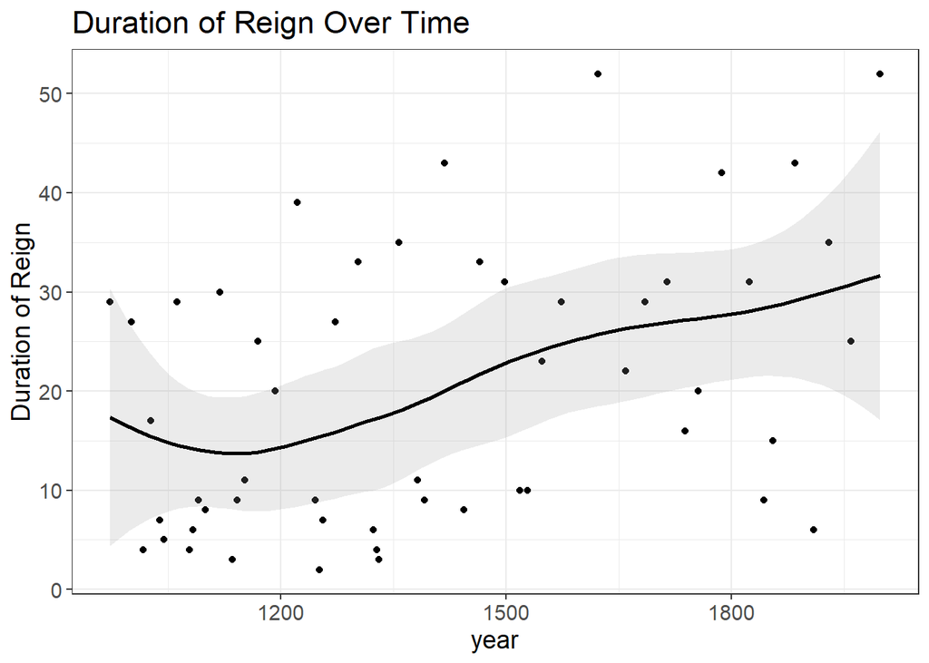

```r
monarchs <- mutate(monarchs_reign_length, midyear = (reign_start_year+(reign_end_year-reign_start_year)/2))

monarchs |> ggplot(aes(x=midyear, y=duration))+geom_point()+geom_smooth(alpha=0.2, colour="black")+labs(title= "Duration of Reign Over Time", x = "year", y = "Duration of Reign")+theme_bw()+theme(text=element_text(size=14))
```

And to submit this rmarkdown, knit it into html. But first, clean up the code chunks, adjust the date, rename the author and change the `eval=FALSE` flag to `eval=TRUE` so your script actually generates an output. Well done!